# **Reconstruction of Total Solar Irradiance by Deep Learning**

# **Table of Contents**

### **Author(s)**

- Author1 = {"name": "Yasser Abduallah", "affiliation": "Department of Computer Science, New Jersey Institute of Technology", "email": "ya54@njit.edu", "orcid": "https://orcid.org/0000-0003-0792-2270%22%7D
- Author2 = {"name": "Jason T. L. Wang", "affiliation": "Department of Computer Science, New Jersey Institute of Technology", "email": "wangj@njit.edu", "orcid": "https://orcid.org/0000-0002-2486-1097%22%7D
- Author3 = {"name": "Yucong Shen", "affiliation": "Department of Computer Science, New Jersey Institute of Technology", "email": "ys496@njit.edu", "orcid": ""}
- Author4 = {"name": "Khalid A. Alobaid", "affiliation": "Department of Computer Science, New Jersey Institute of Technology", "email": "kaa65@njit.edu", "orcid": ""}
- Author5 = {"name": "Serena Criscuoli", "affiliation": "National Solar Observatory, Boulder, Colorado, USA", "email": "scriscuo@nso.edu", "orcid": "0000-0002-4525-9038"}
- Author6 = {"name": "Haimin Wang", "affiliation": "Institute for Space Weather Sciences, New Jersey Institute of Technology", "email": "haimin.wang@njit.edu", "orcid": "https://orcid.org/0000-0002-5233-565X%22%7D

### **Purpose**

In this notebook we provide an overview of the TSInet system to demonstrate how to reconstruct the TSI using deep learning (DL) that goes beyond the phsyical parameters construction limit.

### **Technical Contributions**

- We provide the community with a new tool to reconstruct the total solar irradiance (TSI) for 9,000 years and byone.

### **Methodology**

The figure below presents the architecture of our TSInet model. TSInet is created using the tensorflow keras framework. Let *t* be the latest time point. Data sample *x<sub>t</sub>* contains *w* values *v<sub>t</sub>,v<sub>t−1</sub>,...,v<sub>t−w+1</sub>* and the label *v<sub>t−w</sub>* where *v<sub>t</sub>* is the TSI value at time point *t*. In our study, the time window, *w*, is set to 7. We train TSInet with multiple batches. In the first batch, we use the *n* training data samples, *x<sub>t</sub>,x<sub>t−1</sub>,...,x<sub>t−n+1</sub>*, to train TSInet. In our study, the number of input data samples,*n*, is set to 10. The label of the *n* training data samples is determined by the label of the last data sample (i.e.,*x<sub>t−n+1</sub>*).In the second batch, we use the next *<sub>n</sub>* training data samples, *x<sub>t−n</sub>,x<sub>t−n−1</sub>,...,x<sub>t−2n+1</sub>*, to train TSInet. The label of the *<sub>n</sub>* training data samples is determined by the label of *x<sub>t−2n+1</sub>*. In the third batch, we use the following *n* training data samples,*x<sub>t−2n</sub>,x<sub>t−2n−1</sub>,...,x<sub>t−3n+1, to train TSInet. The label of the</sub>*n* training data samples is determined by the label of *xt−3n+1*. We continue this training process until all TSI values in the training set are used. Forevery two adjacent data samples *x<sub>i</sub>,x<sub>i−1</sub>*, they overlap on *w−1* TSI values, namely *v<sub>i−1</sub>,v<sub>i−2</sub>,...,v<sub>i−w+1</sub>*. TSInet consists of three convolutional layers (Conv1d_1,Conv1d_2, and Conv1d_3) where the kernel slides along 1-dimension on the time series, a max pooling layer, a flatten layer, a repeat vector layer, an LSTM (long short-termmemory) layer, an attention layer, two fully connected layers, and an output layer. The output from the three convolutional layers is flattened by the flatten layer and transformed into a sequence, also known as a feature vector. The repeatvector layer repeats the feature vector to reshape and prepare it as the input to the LSTM layer. The LSTM layer in our architecture contains *m* LSTM cells (in this study,*m* is set to 10). The attention layer with *m* neurons is used to focus on the relevant information in each time step. Each of the two fully connected layers has 200 neurons. The activation function used in our model is ReLU (rectified linear unit). TSInet produces as output a predicted TSI value.

[figure not shown]

TSInet Contextual Architecture.

### **Funding**

N/A

### **Keywords**

keywords=["TSI","solar","irradiance","Reconstruction", "Prediction", "Machine", "Learning"]

### **Citation**

To cite this notebook: Yasser Abduallah, Jason T. L. Wang, Yucong Shen, Khalid A. Alobaid, Serena Criscuoli, Haimin Wang. Reconstruction of Total Solar Irradiance by Deep Learning available at: [https://github.com/ccsc-tools/TSInet-irradiance-reconstruction/YA_01_ReconstructionOfTSIbyDeepLearning.ipynb](https://github.com/ccsc-tools/TSInet-irradiance-reconstruction/blob/main/YA_01_ReconstructionOfTSIbyDeepLearning.ipynb).

### **Acknowledgements**

# **Setup**

**Installation on Local Machine**  
Running this notebook in a local machine requires Python version 3.6.x or 3.8.x with the following packages and their version:

| Library | Version | Description |
| --- | --- | --- |
| keras | 2.3.0 | Deep learning API |
| keras_self_attention | latest | Self attention mechanism |
| numpy | 1.21.5 | Array manipulation |
| sklearn | latest | Tools for predictive data analysis |
| pandas | 1.3.4 | Data loading and manipulation |
| scipy | 1.7.1 | Provides algorithms for optimization and statistics |
| tensorflow | 1.14 or 2.4 | Provides the visualization and tooling needed for machine learning |
| tensorflow-gpu | 1.14 or 2.4 | Deep learning tool for high performance computation |

**Library Import**  
The following libraries need to be imported.

```python
#supress warning messages
import warnings
warnings.filterwarnings('ignore')
print('Importing packages..')
# Data manipulation
import pandas as pd
import numpy as np
import os
print('Packages imported')
```

```
Importing packages..
Packages imported
```

# **Data Processing and Analysis**

We use measurements of the TSI provided by the Total Irradiance Monitor aboard the SOlar Radiation and Climate Experiment (SORCE)(Rottman2005) and available at: http://lasp.colorado.edu/home/sorce/data/tsi-data/. This dataset, used as our training set, contains daily TSI measurements carried outfrom 2003 to the present (2021). Figure 1 illustrates the SORCE time series dataset showing the total solar irradiance overtime.

[figure not shown]

Figure 1: SORCE total solar irradiance (TSI) data from 2003 to the present (2021).

Our testing set contains measurements from TCTE TotalSolar Irradiance daily averages, available athttp://lasp.colorado.edu/lisird/data/tcte_tsi_24hr/. Total Solar Irradiance Calibration Transfer Experiment (TCTE) (http://lasp.colorado.edu/home/missions-projects/quick-facts-tcte/) mea-surements are made by the LASP TCTE Total Irradiance Monitor (TIM) instrument aboard the U.S. Air Force’s STPSat-3 spacecraft. This TIM has been measuring total solar irradiance since late 2013. In addition, we adopt the following publicly available datasets obtained, over different temporal ranges, by different physics-based models, which will are used as testing setsin our work:

- NRLTSI2 (Naval Research Lab-oratory’s TSI-2) Daily Averages, available at: http://lasp.colorado.edu/lisird/
- SATIRE-S (Spectral And Total Irradiance RE-construction model-Space era), available at: http://www2.mps.mpg.de/projects/sun-climate/data.html
- SATIRE-M (Spectral And Total Irradiance RE-construction model - Millennia), available at: http://www2.mps.mpg.de/projects

The total solar irradiance values range from 1356.656 to 1363.525. We use a feature scaling technique, also known as data normalization, to normalize the range of data to increase the cohesion of the TSI values. Specifically, we use the min-max normalization that is calculated as follows:

[figure not shown]

where *v̂<sub>i</sub>*(*v<sub>i</sub>*, respectively) is the normalized value (actualvalue, respectively) at time pointi, and *S* represents the input data set. The normalized TSI values range from 0 to 1.  
Figure 2 shows the data scaling while keeping the same data shape as the original data as seen in Figure 1.

[figure not shown]

# **Binder**

Please note that starting Binder might take some time to create and start the image.

# **TSInet Workflow and Results**

### **Data Preparation and Loading**

The required files are included in the root folder of the github which includes all training and test data sets required to run the run the notebook. The files are loaded and used during the testing and training process.

### **Reconstructing with Pretrained Models**

There are default and pretrained models that can be used to predict without running your own trained model. The models_directory is set to default_models which uses all pretrained algorithms.

```python
#Test default models.
from tsinet_reconstructor import *
dataset_name='TCTE'
model_directory='default_model'
print('Testing the default model with data set:', dataset_name)
args={}

args['dataset_name'] = dataset_name
args['model_dir']  = model_directory
print('Process the require arguments..')
process_args(args)

reconstruct_tsinet()
```

```
Python version: 3.8.13
Tensorflow backend version: 2.4.0
Testing the default model with data set: TCTE
Process the require arguments..
model_dir: default_model

Please wait while reconstructing...
Loading model file: default_model\tsinet_model
Reconstruction will be performed using the model file: default_model\tsinet_model
Processing with k steps = 5
Finished the reconstruction process.
Results are written to: results\tsinet_result_TCTE.csv
```

[output not shown]

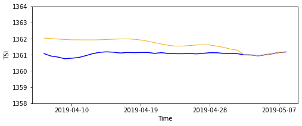

```python
from tsinet_utils import plot_figures

dataset_name='TCTE'
result_file_name = 'results/tsinet_result_' + dataset_name + '.csv'
print('Plotting figures for default models results for TSI reconstruction of data set:', dataset_name)
plot_figures(result_file_name)
```